# SPSS_Output_lesson22

[output not shown]

Log  
Log - Log - November 12, 2017

GET  
FILE='C:\MyGithub\N736Fall2017_lesson22\helpmkh.sav'.  
DATASET NAME DataSet1 WINDOW=FRONT.  
FREQUENCIES VARIABLES=pcs pcs1 pcs2 pcs3 pcs4  
/FORMAT=NOTABLE  
/NTILES=4  
/STATISTICS=STDDEV MINIMUM MAXIMUM MEAN  
/HISTOGRAM  
/ORDER=ANALYSIS.

Frequencies  
Frequencies - Active Dataset - November 12, 2017

[DataSet1] C:\MyGithub\N736Fall2017_lesson22\helpmkh.sav

Frequencies  
Frequencies - Statistics - November 12, 2017

StatisticsStatistics, table, 1 levels of column headers and 2 levels of row headers, table with 7 columns and 11 rows

|  |  | pcs SF36 Physical Composite Score - Baseline | pcs1 SF36 Physical Composite Score - 6mo | pcs2 SF36 Physical Composite Score - 12mo | pcs3 SF36 Physical Composite Score - 18mo | pcs4 SF36 Physical Composite Score - 24mo |
| --- | --- | --- | --- | --- | --- | --- |
| N | Valid | 453 | 246 | 211 | 248 | 266 |
|  | Missing | 0 | 207 | 242 | 205 | 187 |
| Mean |  | 48.048541551131024 | 50.157816468215570 | 50.024775170601940 | 49.095757953582270 | 49.764476471377490 |
| Std. Deviation |  | 10.784602685414233 | 10.349064888277008 | 10.400167371223002 | 11.136411543036814 | 10.094956604894879 |
| Minimum |  | 14.0742912292480 | 19.6958732604980 | 14.4435892105103 | 18.5182132720947 | 15.4147710800171 |
| Maximum |  | 74.8063278198242 | 71.4448089599609 | 68.9317703247070 | 71.2912979125977 | 69.7208938598633 |
| Percentiles | 25 | 40.313543319702150 | 42.698200225830070 | 42.949081420898400 | 41.379487991333030 | 43.114171028137200 |
|  | 50 | 48.876808166503900 | 53.324293136596700 | 53.374019622802700 | 51.799209594726600 | 52.872819900512695 |
|  | 75 | 56.953582763671900 | 58.175192832946800 | 58.145622253418000 | 57.499963760375950 | 57.430876731872570 |

Histogram  
Histogram - SF36 Physical Composite Score - Baseline - November 12, 2017

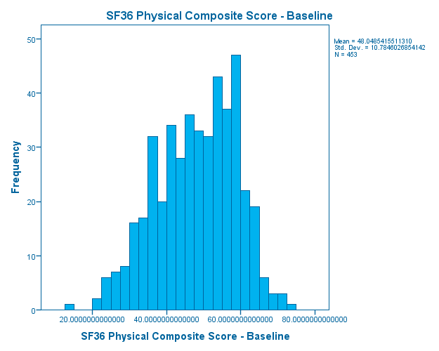

Histogram  
Histogram - SF36 Physical Composite Score - 6mo - November 12, 2017

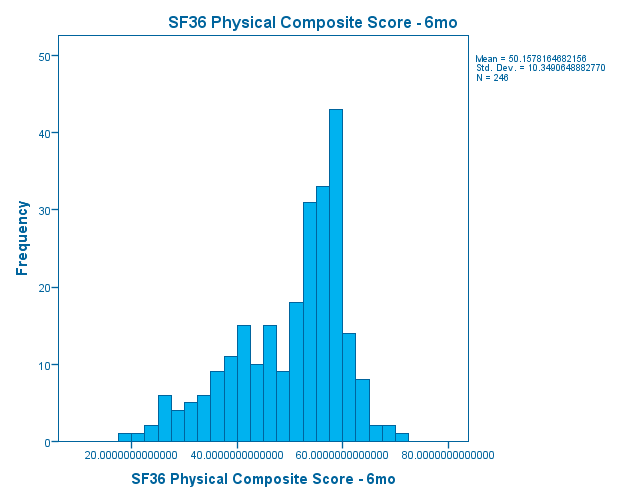

Histogram  
Histogram - SF36 Physical Composite Score - 12mo - November 12, 2017

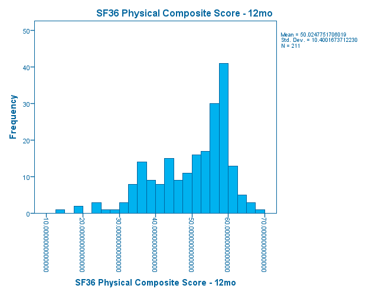

Histogram  
Histogram - SF36 Physical Composite Score - 18mo - November 12, 2017

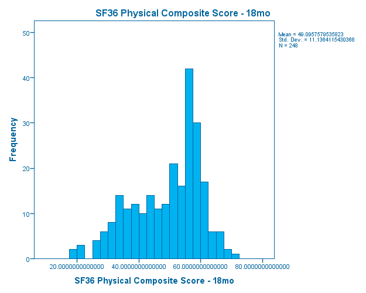

Histogram  
Histogram - SF36 Physical Composite Score - 24mo - November 12, 2017

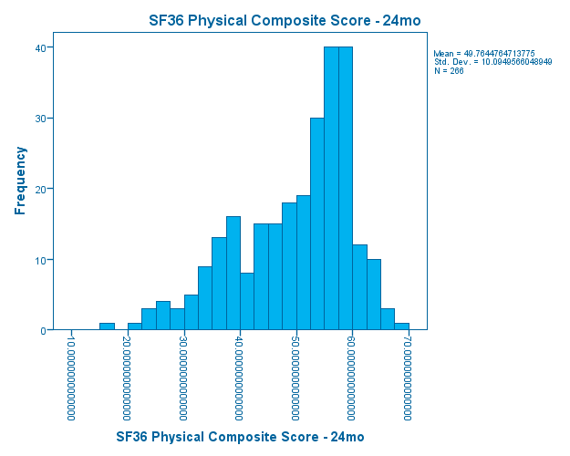

Log  
Log - Log - November 12, 2017

EXAMINE VARIABLES=pcs pcs1 pcs2 pcs3 pcs4  
/PLOT BOXPLOT HISTOGRAM NPPLOT  
/COMPARE GROUPS  
/STATISTICS DESCRIPTIVES  
/CINTERVAL 95  
/MISSING LISTWISE  
/NOTOTAL.

Explore  
Explore - Case Processing Summary - November 12, 2017

Case Processing SummaryCase Processing Summary, table, 3 levels of column headers and 1 levels of row headers, table with 7 columns and 9 rows

|  | Cases |  |  |  |  |  |
| --- | --- | --- | --- | --- | --- | --- |
|  | Valid |  | Missing |  | Total |  |
|  | N | Percent | N | Percent | N | Percent |
| pcs SF36 Physical Composite Score - Baseline | 98 | 21.6% | 355 | 78.4% | 453 | 100.0% |
| pcs1 SF36 Physical Composite Score - 6mo | 98 | 21.6% | 355 | 78.4% | 453 | 100.0% |
| pcs2 SF36 Physical Composite Score - 12mo | 98 | 21.6% | 355 | 78.4% | 453 | 100.0% |
| pcs3 SF36 Physical Composite Score - 18mo | 98 | 21.6% | 355 | 78.4% | 453 | 100.0% |
| pcs4 SF36 Physical Composite Score - 24mo | 98 | 21.6% | 355 | 78.4% | 453 | 100.0% |

Explore  
Explore - Descriptives - November 12, 2017

DescriptivesDescriptives, table, 1 levels of column headers and 3 levels of row headers, table with 5 columns and 67 rows

|  |  |  | Statistic | Std. Error |
| --- | --- | --- | --- | --- |
| pcs SF36 Physical Composite Score - Baseline | Mean |  | 47.793844884755660 | 1.134899663447092 |
|  | 95% Confidence Interval for Mean | Lower Bound | 45.541383208913246 |  |
|  |  | Upper Bound | 50.046306560598070 |  |
|  | 5% Trimmed Mean |  | 48.096149859785214 |  |
|  | Median |  | 48.924282073974595 |  |
|  | Variance |  | 126.224 |  |
|  | Std. Deviation |  | 11.234933471856774 |  |
|  | Minimum |  | 20.7402915954590 |  |
|  | Maximum |  | 68.1239547729492 |  |
|  | Range |  | 47.3836631774902 |  |
|  | Interquartile Range |  | 18.7728242874146 |  |
|  | Skewness |  | -.373 | .244 |
|  | Kurtosis |  | -.722 | .483 |
| pcs1 SF36 Physical Composite Score - 6mo | Mean |  | 48.779843583398936 | 1.134148736512487 |
|  | 95% Confidence Interval for Mean | Lower Bound | 46.528872289654636 |  |
|  |  | Upper Bound | 51.030814877143236 |  |
|  | 5% Trimmed Mean |  | 49.158683964995290 |  |
|  | Median |  | 52.132347106933550 |  |
|  | Variance |  | 126.057 |  |
|  | Std. Deviation |  | 11.227499674469879 |  |
|  | Minimum |  | 19.6958732604980 |  |
|  | Maximum |  | 71.4448089599609 |  |
|  | Range |  | 51.7489356994629 |  |
|  | Interquartile Range |  | 16.6572999954223 |  |
|  | Skewness |  | -.635 | .244 |
|  | Kurtosis |  | -.312 | .483 |
| pcs2 SF36 Physical Composite Score - 12mo | Mean |  | 49.919714567612630 | 1.020965489781992 |
|  | 95% Confidence Interval for Mean | Lower Bound | 47.893380687922640 |  |
|  |  | Upper Bound | 51.946048447302620 |  |
|  | 5% Trimmed Mean |  | 50.722028727974750 |  |
|  | Median |  | 54.653566360473600 |  |
|  | Variance |  | 102.152 |  |
|  | Std. Deviation |  | 10.107042696552083 |  |
|  | Minimum |  | 14.4435892105103 |  |
|  | Maximum |  | 61.8165359497070 |  |
|  | Range |  | 47.3729467391967 |  |
|  | Interquartile Range |  | 14.7175407409668 |  |
|  | Skewness |  | -1.159 | .244 |
|  | Kurtosis |  | .976 | .483 |
| pcs3 SF36 Physical Composite Score - 18mo | Mean |  | 50.320825168064665 | 1.132387439721982 |
|  | 95% Confidence Interval for Mean | Lower Bound | 48.073349560897930 |  |
|  |  | Upper Bound | 52.568300775231400 |  |
|  | 5% Trimmed Mean |  | 50.894580326383070 |  |
|  | Median |  | 55.219718933105500 |  |
|  | Variance |  | 125.666 |  |
|  | Std. Deviation |  | 11.210063725810410 |  |
|  | Minimum |  | 18.5182132720947 |  |
|  | Maximum |  | 71.2912979125977 |  |
|  | Range |  | 52.7730846405030 |  |
|  | Interquartile Range |  | 15.5454816818238 |  |
|  | Skewness |  | -.868 | .244 |
|  | Kurtosis |  | .033 | .483 |
| pcs4 SF36 Physical Composite Score - 24mo | Mean |  | 49.430703591327280 | .947632371411137 |
|  | 95% Confidence Interval for Mean | Lower Bound | 47.549915651970600 |  |
|  |  | Upper Bound | 51.311491530683960 |  |
|  | 5% Trimmed Mean |  | 49.894150439844104 |  |
|  | Median |  | 53.140966415405245 |  |
|  | Variance |  | 88.005 |  |
|  | Std. Deviation |  | 9.381081862553852 |  |
|  | Minimum |  | 24.3201255798340 |  |
|  | Maximum |  | 65.2547454833984 |  |
|  | Range |  | 40.9346199035644 |  |
|  | Interquartile Range |  | 13.1018228530884 |  |
|  | Skewness |  | -.803 | .244 |
|  | Kurtosis |  | -.165 | .483 |

Explore  
Explore - Tests of Normality - November 12, 2017

Tests of NormalityTests of Normality, table, 2 levels of column headers and 1 levels of row headers, table with 7 columns and 9 rows

|  | Kolmogorov-Smirnov<sup>a</sup> |  |  | Shapiro-Wilk |  |  |
| --- | --- | --- | --- | --- | --- | --- |
|  | Statistic | df | Sig. | Statistic | df | Sig. |
| pcs SF36 Physical Composite Score - Baseline | .098 | 98 | .022 | .968 | 98 | .016 |
| pcs1 SF36 Physical Composite Score - 6mo | .145 | 98 | .000 | .948 | 98 | .001 |
| pcs2 SF36 Physical Composite Score - 12mo | .186 | 98 | .000 | .869 | 98 | .000 |
| pcs3 SF36 Physical Composite Score - 18mo | .184 | 98 | .000 | .912 | 98 | .000 |
| pcs4 SF36 Physical Composite Score - 24mo | .163 | 98 | .000 | .923 | 98 | .000 |

a. Lilliefors Significance Correction

pcs SF36 Physical Composite Score - Baseline  
pcs SF36 Physical Composite Score - Baseline - Histogram - November 12, 2017

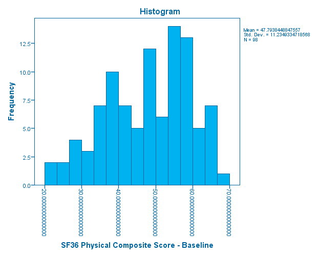

pcs SF36 Physical Composite Score - Baseline  
pcs SF36 Physical Composite Score - Baseline - Normal Q-Q Plot - November 12, 2017

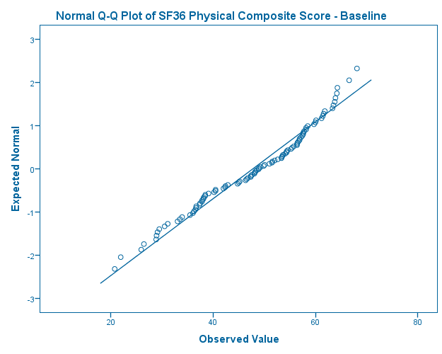

pcs SF36 Physical Composite Score - Baseline  
pcs SF36 Physical Composite Score - Baseline - Detrended Normal Q-Q Plot - November 12, 2017

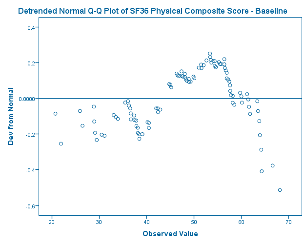

pcs SF36 Physical Composite Score - Baseline  
pcs SF36 Physical Composite Score - Baseline - Boxplot - November 12, 2017

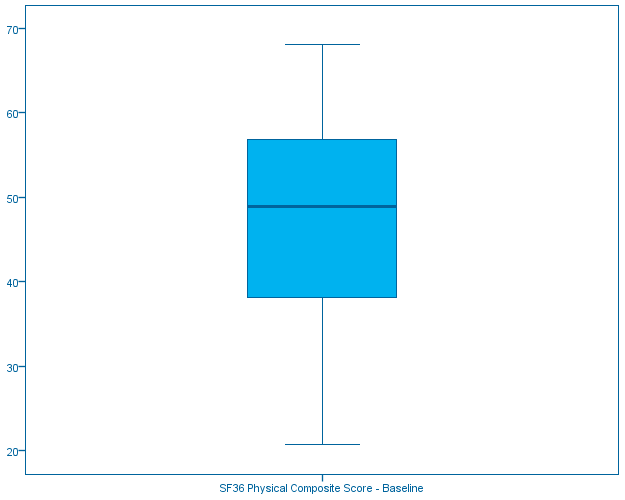

pcs1 SF36 Physical Composite Score - 6mo  
pcs1 SF36 Physical Composite Score - 6mo - Histogram - November 12, 2017

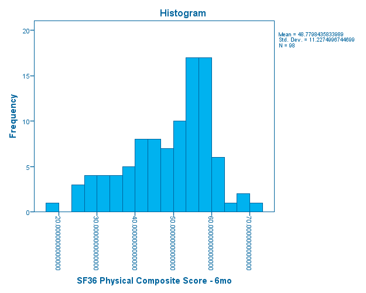

pcs1 SF36 Physical Composite Score - 6mo  
pcs1 SF36 Physical Composite Score - 6mo - Normal Q-Q Plot - November 12, 2017

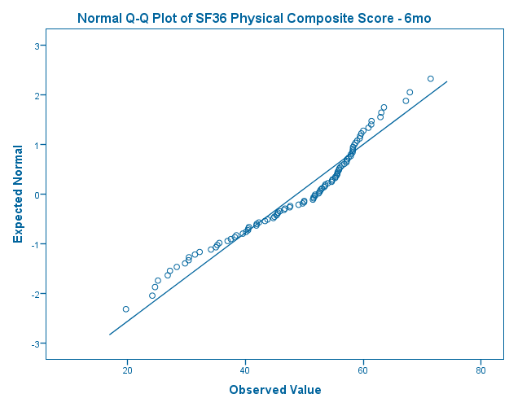

pcs1 SF36 Physical Composite Score - 6mo  
pcs1 SF36 Physical Composite Score - 6mo - Detrended Normal Q-Q Plot - November 12, 2017

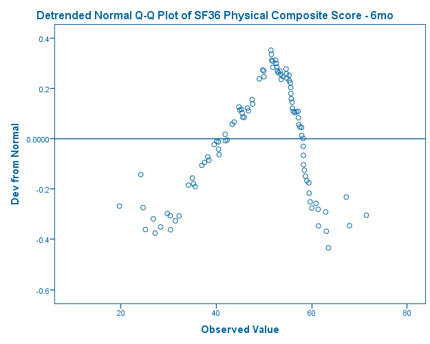

pcs1 SF36 Physical Composite Score - 6mo  
pcs1 SF36 Physical Composite Score - 6mo - Boxplot - November 12, 2017

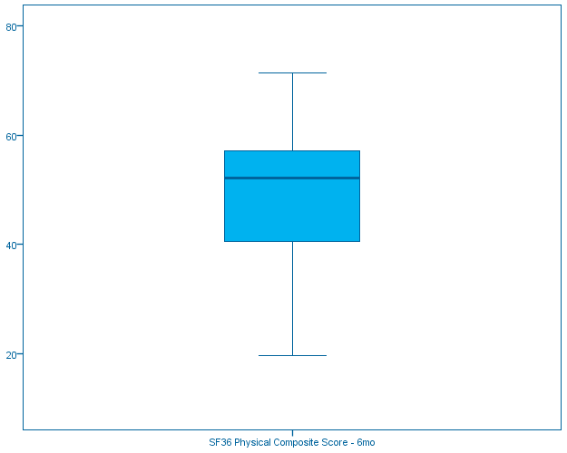

pcs2 SF36 Physical Composite Score - 12mo  
pcs2 SF36 Physical Composite Score - 12mo - Histogram - November 12, 2017

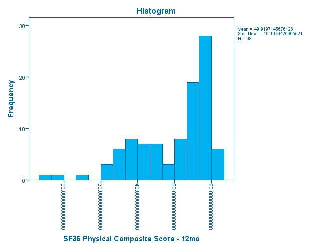

pcs2 SF36 Physical Composite Score - 12mo  
pcs2 SF36 Physical Composite Score - 12mo - Normal Q-Q Plot - November 12, 2017

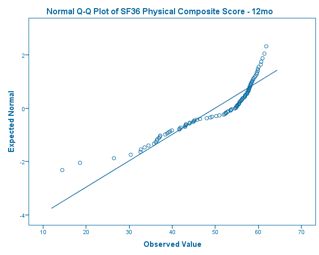

pcs2 SF36 Physical Composite Score - 12mo  
pcs2 SF36 Physical Composite Score - 12mo - Detrended Normal Q-Q Plot - November 12, 2017

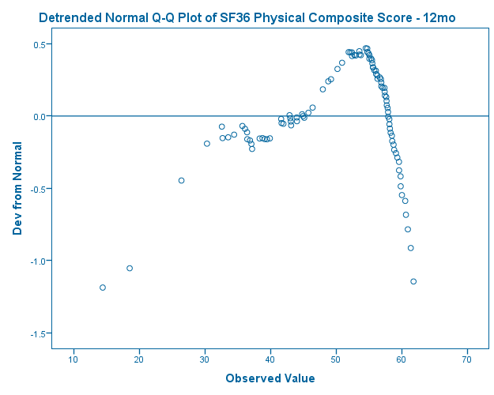

pcs2 SF36 Physical Composite Score - 12mo  
pcs2 SF36 Physical Composite Score - 12mo - Boxplot - November 12, 2017

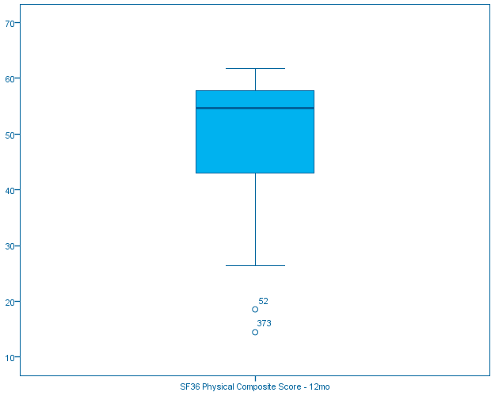

pcs3 SF36 Physical Composite Score - 18mo  
pcs3 SF36 Physical Composite Score - 18mo - Histogram - November 12, 2017

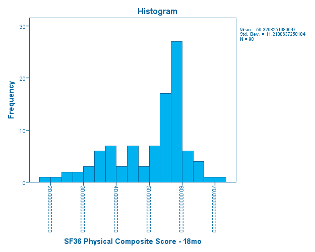

pcs3 SF36 Physical Composite Score - 18mo  
pcs3 SF36 Physical Composite Score - 18mo - Normal Q-Q Plot - November 12, 2017

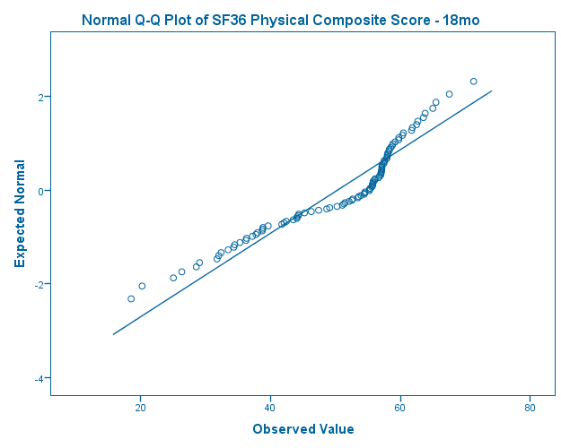

pcs3 SF36 Physical Composite Score - 18mo  
pcs3 SF36 Physical Composite Score - 18mo - Detrended Normal Q-Q Plot - November 12, 2017

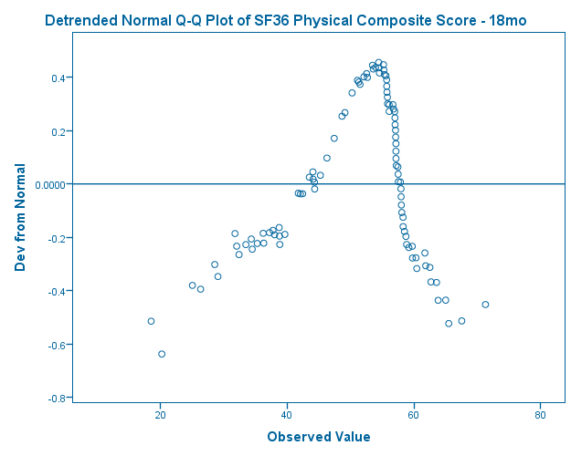

pcs3 SF36 Physical Composite Score - 18mo  
pcs3 SF36 Physical Composite Score - 18mo - Boxplot - November 12, 2017

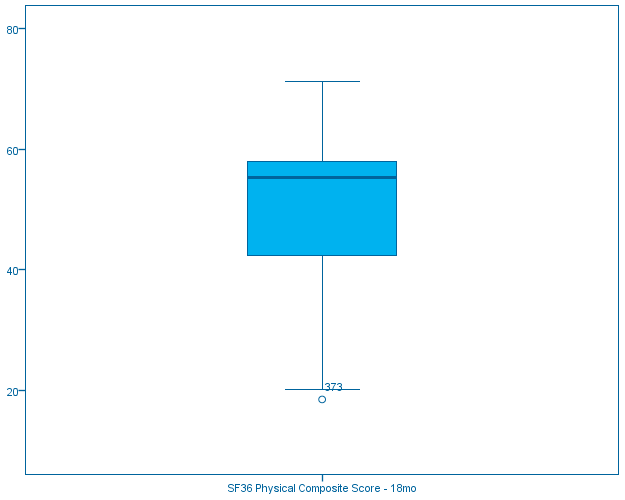

pcs4 SF36 Physical Composite Score - 24mo  
pcs4 SF36 Physical Composite Score - 24mo - Histogram - November 12, 2017

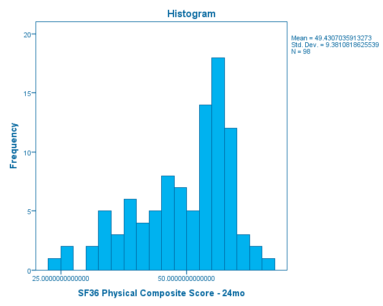

pcs4 SF36 Physical Composite Score - 24mo  
pcs4 SF36 Physical Composite Score - 24mo - Normal Q-Q Plot - November 12, 2017

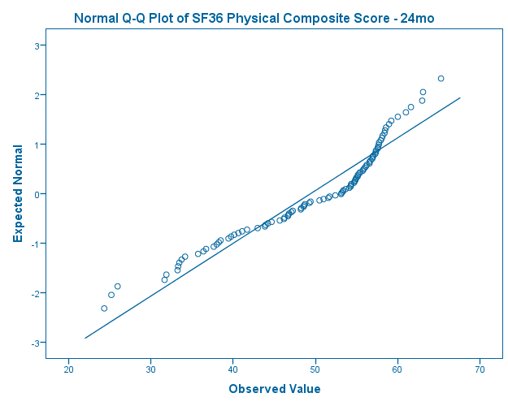

pcs4 SF36 Physical Composite Score - 24mo  
pcs4 SF36 Physical Composite Score - 24mo - Detrended Normal Q-Q Plot - November 12, 2017

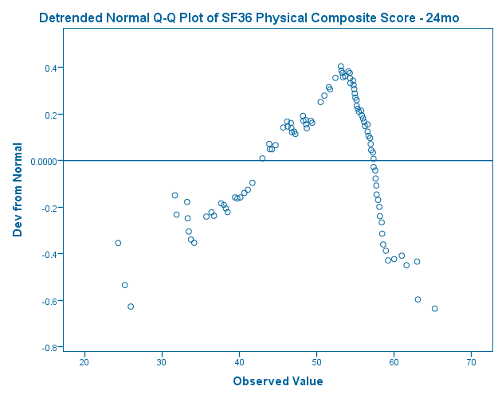

pcs4 SF36 Physical Composite Score - 24mo  
pcs4 SF36 Physical Composite Score - 24mo - Boxplot - November 12, 2017

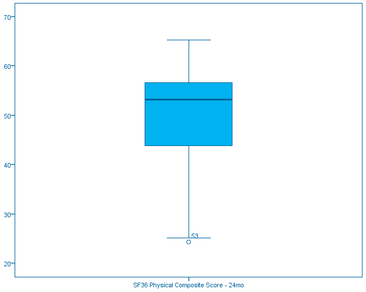

Log  
Log - Log - November 12, 2017

EXAMINE VARIABLES=pcs pcs1 pcs2 pcs3 pcs4 BY treat  
/PLOT BOXPLOT HISTOGRAM NPPLOT  
/COMPARE GROUPS  
/STATISTICS DESCRIPTIVES  
/CINTERVAL 95  
/MISSING LISTWISE  
/NOTOTAL.

treat Randomization Group  
treat Randomization Group - Case Processing Summary - November 12, 2017

Case Processing SummaryCase Processing Summary, table, 3 levels of column headers and 2 levels of row headers, table with 8 columns and 14 rows

|  | treat Randomization Group | Cases |  |  |  |  |  |
| --- | --- | --- | --- | --- | --- | --- | --- |
|  |  | Valid |  | Missing |  | Total |  |
|  |  | N | Percent | N | Percent | N | Percent |
| pcs SF36 Physical Composite Score - Baseline | 0 usual care | 46 | 20.2% | 182 | 79.8% | 228 | 100.0% |
|  | 1 HELP clinic | 52 | 23.1% | 173 | 76.9% | 225 | 100.0% |
| pcs1 SF36 Physical Composite Score - 6mo | 0 usual care | 46 | 20.2% | 182 | 79.8% | 228 | 100.0% |
|  | 1 HELP clinic | 52 | 23.1% | 173 | 76.9% | 225 | 100.0% |
| pcs2 SF36 Physical Composite Score - 12mo | 0 usual care | 46 | 20.2% | 182 | 79.8% | 228 | 100.0% |
|  | 1 HELP clinic | 52 | 23.1% | 173 | 76.9% | 225 | 100.0% |
| pcs3 SF36 Physical Composite Score - 18mo | 0 usual care | 46 | 20.2% | 182 | 79.8% | 228 | 100.0% |
|  | 1 HELP clinic | 52 | 23.1% | 173 | 76.9% | 225 | 100.0% |
| pcs4 SF36 Physical Composite Score - 24mo | 0 usual care | 46 | 20.2% | 182 | 79.8% | 228 | 100.0% |
|  | 1 HELP clinic | 52 | 23.1% | 173 | 76.9% | 225 | 100.0% |

treat Randomization Group  
treat Randomization Group - Descriptives - November 12, 2017

DescriptivesDescriptives, table, 1 levels of column headers and 4 levels of row headers, table with 6 columns and 132 rows

|  | treat Randomization Group |  |  | Statistic | Std. Error |
| --- | --- | --- | --- | --- | --- |
| pcs SF36 Physical Composite Score - Baseline | 0 usual care | Mean |  | 46.767339623492695 | 1.740476427618684 |
|  |  | 95% Confidence Interval for Mean | Lower Bound | 43.261840152359230 |  |
|  |  |  | Upper Bound | 50.272839094626164 |  |
|  |  | 5% Trimmed Mean |  | 47.030812139096476 |  |
|  |  | Median |  | 45.974805831909150 |  |
|  |  | Variance |  | 139.346 |  |
|  |  | Std. Deviation |  | 11.804485459960953 |  |
|  |  | Minimum |  | 21.9190559387207 |  |
|  |  | Maximum |  | 64.2902221679688 |  |
|  |  | Range |  | 42.3711662292481 |  |
|  |  | Interquartile Range |  | 20.5917587280273 |  |
|  |  | Skewness |  | -.160 | .350 |
|  |  | Kurtosis |  | -1.191 | .688 |
|  | 1 HELP clinic | Mean |  | 48.701907231257500 | 1.489251148208641 |
|  |  | 95% Confidence Interval for Mean | Lower Bound | 45.712110796190120 |  |
|  |  |  | Upper Bound | 51.691703666324884 |  |
|  |  | 5% Trimmed Mean |  | 49.038568276625410 |  |
|  |  | Median |  | 49.970930099487300 |  |
|  |  | Variance |  | 115.329 |  |
|  |  | Std. Deviation |  | 10.739142753819749 |  |
|  |  | Minimum |  | 20.7402915954590 |  |
|  |  | Maximum |  | 68.1239547729492 |  |
|  |  | Range |  | 47.3836631774902 |  |
|  |  | Interquartile Range |  | 13.4452543258667 |  |
|  |  | Skewness |  | -.586 | .330 |
|  |  | Kurtosis |  | -.005 | .650 |
| pcs1 SF36 Physical Composite Score - 6mo | 0 usual care | Mean |  | 46.847589161085050 | 1.524113230198561 |
|  |  | 95% Confidence Interval for Mean | Lower Bound | 43.777867539104480 |  |
|  |  |  | Upper Bound | 49.917310783065616 |  |
|  |  | 5% Trimmed Mean |  | 47.155960073793570 |  |

[output cut: 100 more lines]

treat Randomization Group  
treat Randomization Group - Tests of Normality - November 12, 2017

Tests of NormalityTests of Normality, table, 2 levels of column headers and 2 levels of row headers, table with 8 columns and 14 rows

|  | treat Randomization Group | Kolmogorov-Smirnov<sup>a</sup> |  |  | Shapiro-Wilk |  |  |
| --- | --- | --- | --- | --- | --- | --- | --- |
|  |  | Statistic | df | Sig. | Statistic | df | Sig. |
| pcs SF36 Physical Composite Score - Baseline | 0 usual care | .162 | 46 | .004 | .935 | 46 | .013 |
|  | 1 HELP clinic | .124 | 52 | .043 | .964 | 52 | .122 |
| pcs1 SF36 Physical Composite Score - 6mo | 0 usual care | .122 | 46 | .084 | .949 | 46 | .041 |
|  | 1 HELP clinic | .209 | 52 | .000 | .919 | 52 | .002 |
| pcs2 SF36 Physical Composite Score - 12mo | 0 usual care | .210 | 46 | .000 | .859 | 46 | .000 |
|  | 1 HELP clinic | .196 | 52 | .000 | .873 | 52 | .000 |
| pcs3 SF36 Physical Composite Score - 18mo | 0 usual care | .217 | 46 | .000 | .881 | 46 | .000 |
|  | 1 HELP clinic | .184 | 52 | .000 | .893 | 52 | .000 |
| pcs4 SF36 Physical Composite Score - 24mo | 0 usual care | .203 | 46 | .000 | .922 | 46 | .004 |
|  | 1 HELP clinic | .148 | 52 | .006 | .911 | 52 | .001 |

a. Lilliefors Significance Correction

Histograms  
Histograms - treat= usual care - November 12, 2017

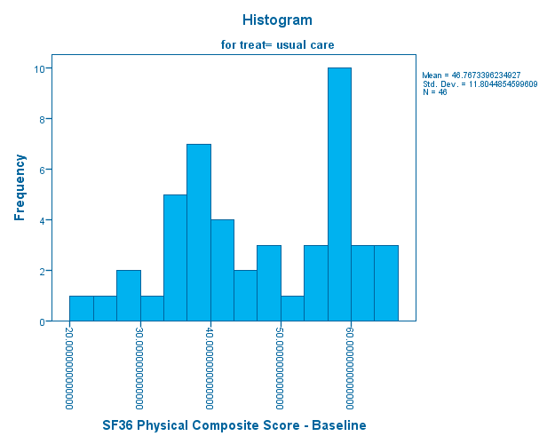

Histograms  
Histograms - treat= HELP clinic - November 12, 2017

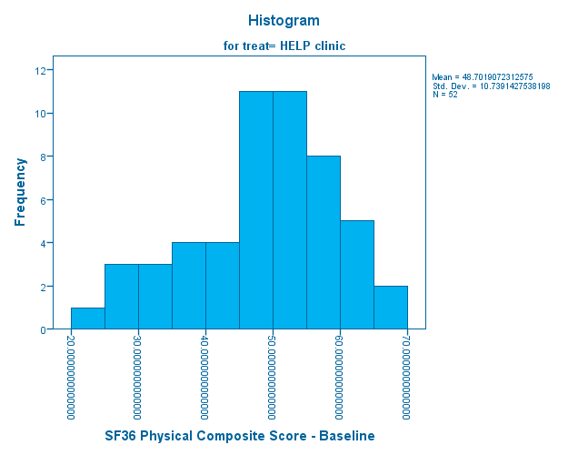

Normal Q-Q Plots  
Normal Q-Q Plots - treat= usual care - November 12, 2017

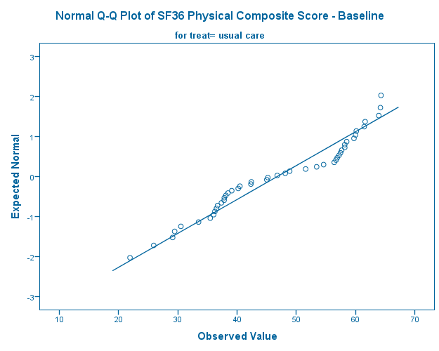

Normal Q-Q Plots  
Normal Q-Q Plots - treat= HELP clinic - November 12, 2017

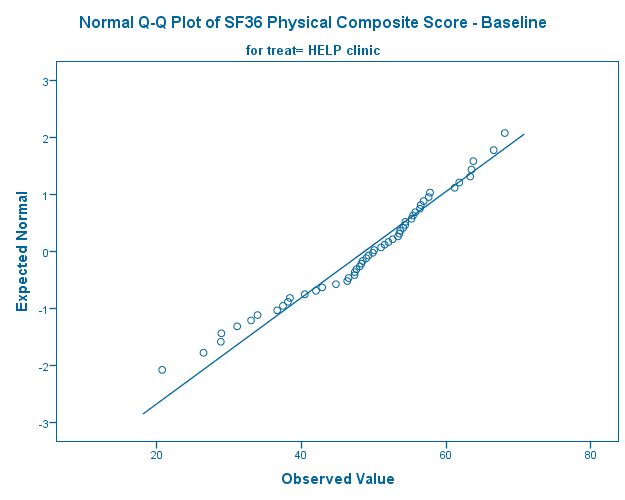

Detrended Normal Q-Q Plots  
Detrended Normal Q-Q Plots - treat= usual care - November 12, 2017

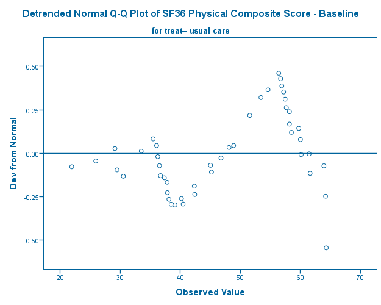

Detrended Normal Q-Q Plots  
Detrended Normal Q-Q Plots - treat= HELP clinic - November 12, 2017

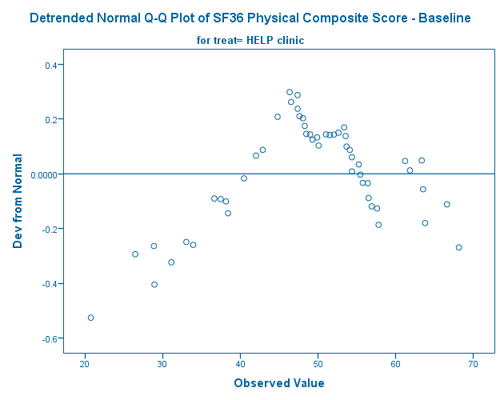

pcs SF36 Physical Composite Score - Baseline  
pcs SF36 Physical Composite Score - Baseline - Boxplot - November 12, 2017

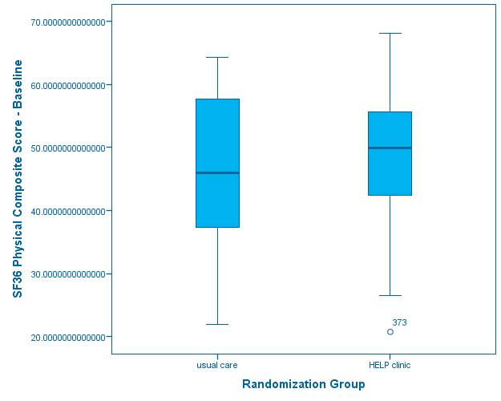

Histograms  
Histograms - treat= usual care - November 12, 2017

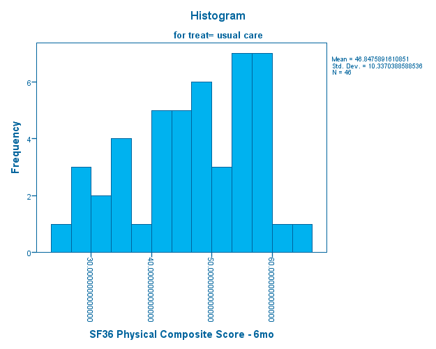

Histograms  
Histograms - treat= HELP clinic - November 12, 2017

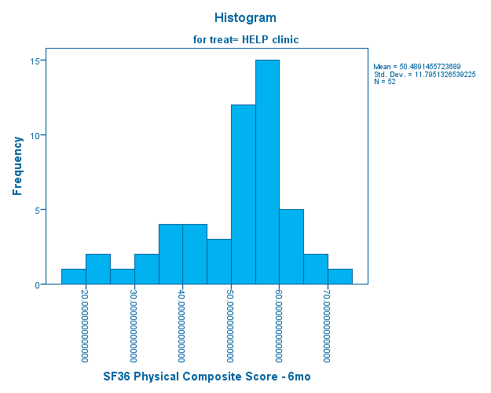

Normal Q-Q Plots  
Normal Q-Q Plots - treat= usual care - November 12, 2017

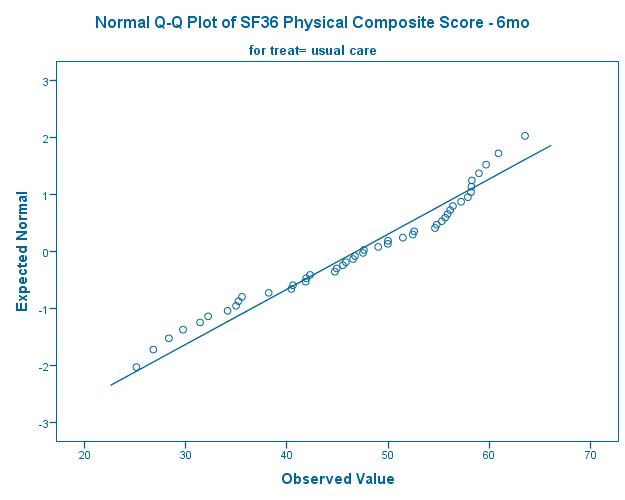

Normal Q-Q Plots  
Normal Q-Q Plots - treat= HELP clinic - November 12, 2017

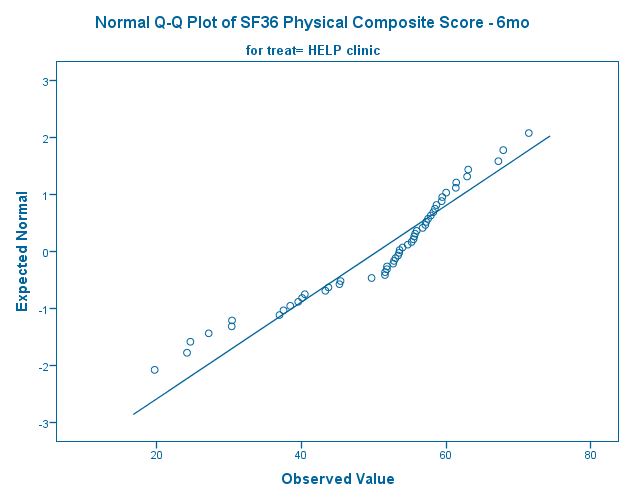

Detrended Normal Q-Q Plots  
Detrended Normal Q-Q Plots - treat= usual care - November 12, 2017

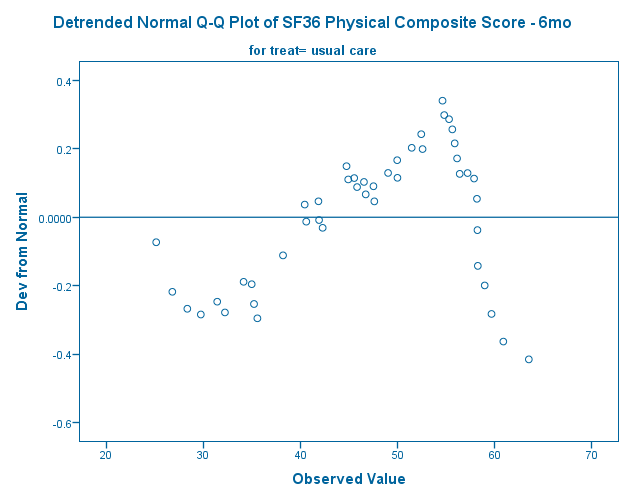

Detrended Normal Q-Q Plots  
Detrended Normal Q-Q Plots - treat= HELP clinic - November 12, 2017

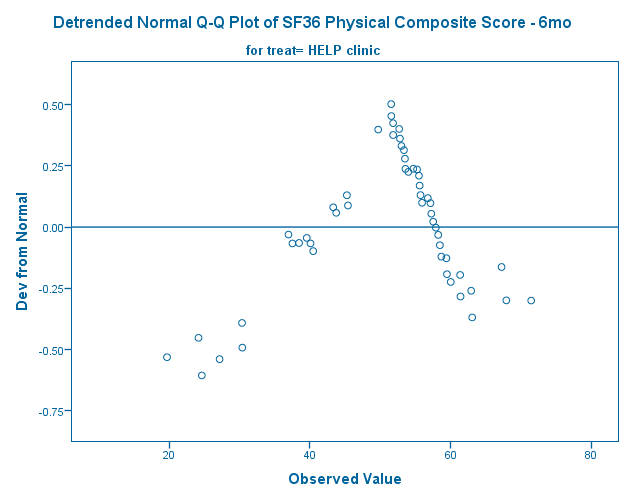

pcs1 SF36 Physical Composite Score - 6mo  
pcs1 SF36 Physical Composite Score - 6mo - Boxplot - November 12, 2017

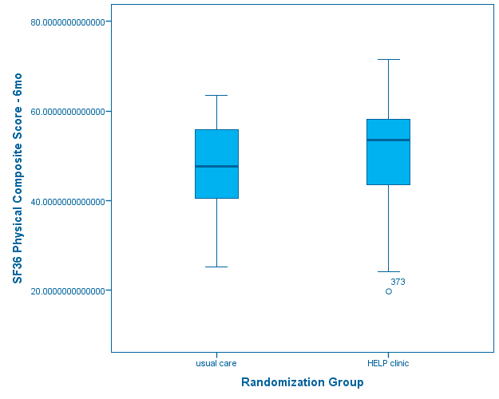

Histograms  
Histograms - treat= usual care - November 12, 2017

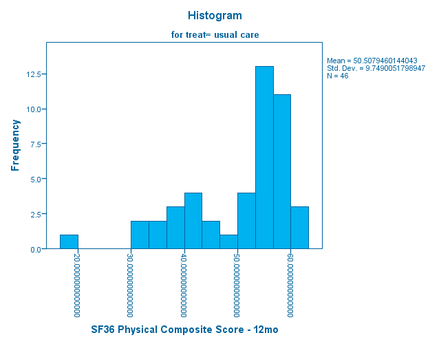

Histograms  
Histograms - treat= HELP clinic - November 12, 2017

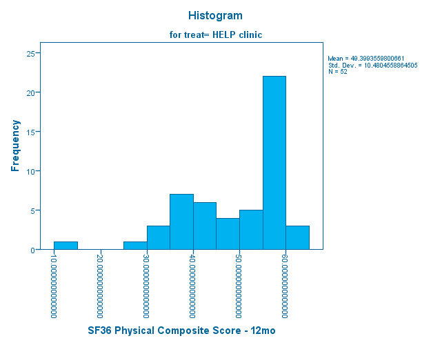

Normal Q-Q Plots  
Normal Q-Q Plots - treat= usual care - November 12, 2017

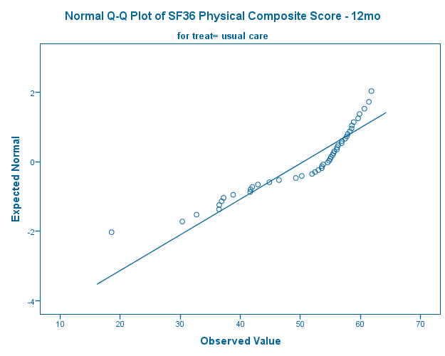

Normal Q-Q Plots  
Normal Q-Q Plots - treat= HELP clinic - November 12, 2017

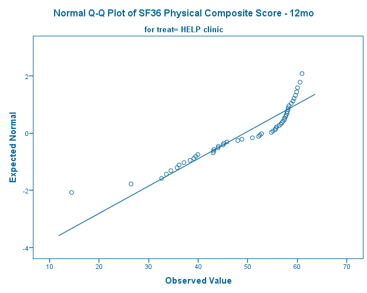

Detrended Normal Q-Q Plots  
Detrended Normal Q-Q Plots - treat= usual care - November 12, 2017

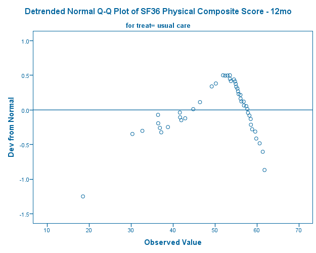

Detrended Normal Q-Q Plots  
Detrended Normal Q-Q Plots - treat= HELP clinic - November 12, 2017

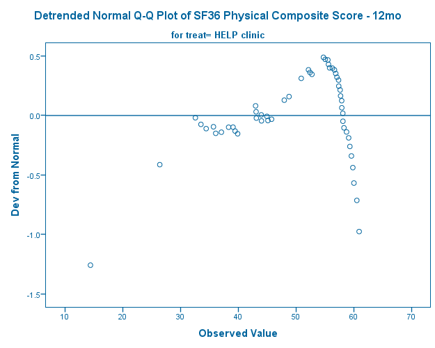

pcs2 SF36 Physical Composite Score - 12mo  
pcs2 SF36 Physical Composite Score - 12mo - Boxplot - November 12, 2017

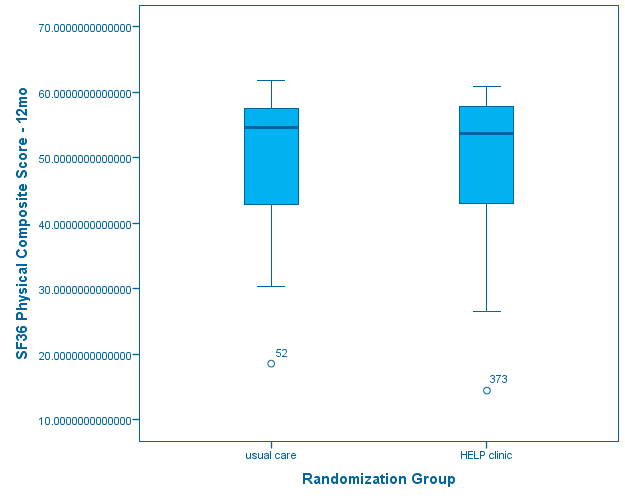

Histograms  
Histograms - treat= usual care - November 12, 2017

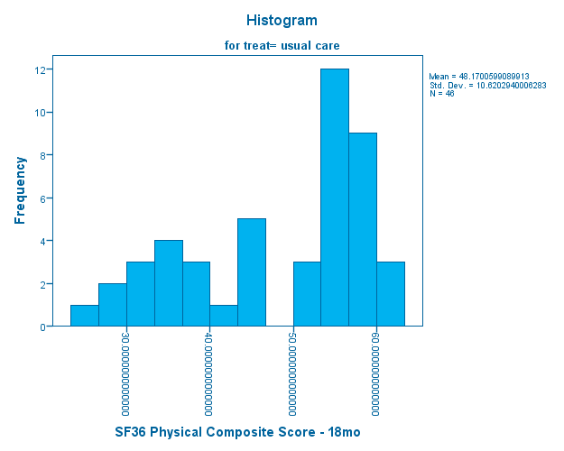

Histograms  
Histograms - treat= HELP clinic - November 12, 2017

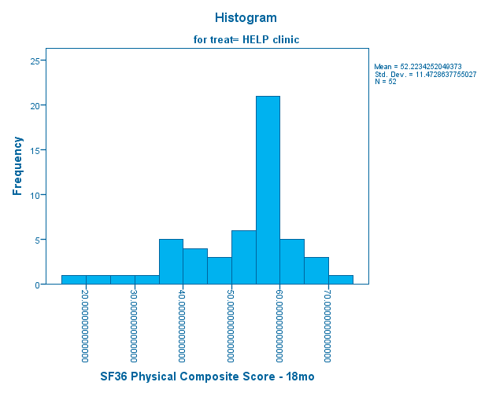

Normal Q-Q Plots  
Normal Q-Q Plots - treat= usual care - November 12, 2017

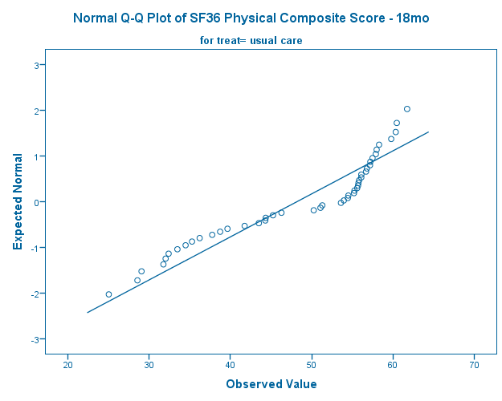

Normal Q-Q Plots  
Normal Q-Q Plots - treat= HELP clinic - November 12, 2017

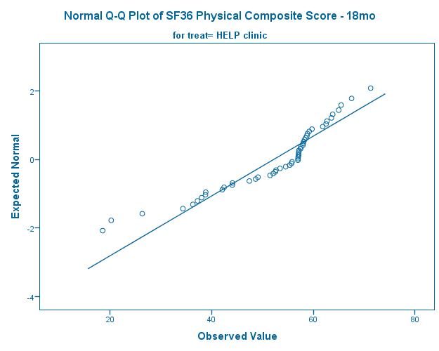

Detrended Normal Q-Q Plots  
Detrended Normal Q-Q Plots - treat= usual care - November 12, 2017

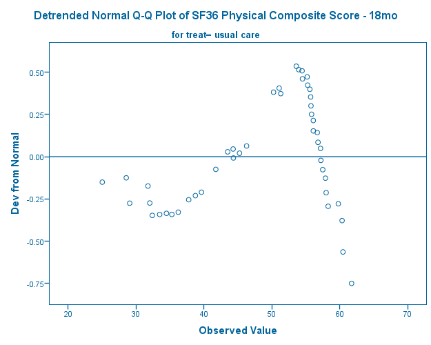

Detrended Normal Q-Q Plots  
Detrended Normal Q-Q Plots - treat= HELP clinic - November 12, 2017

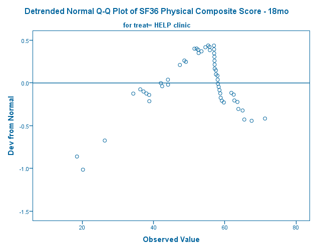

pcs3 SF36 Physical Composite Score - 18mo  
pcs3 SF36 Physical Composite Score - 18mo - Boxplot - November 12, 2017

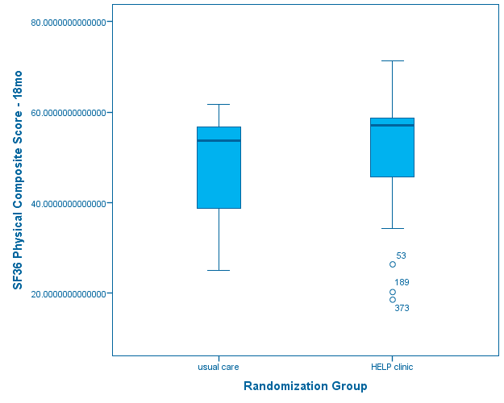

Histograms  
Histograms - treat= usual care - November 12, 2017

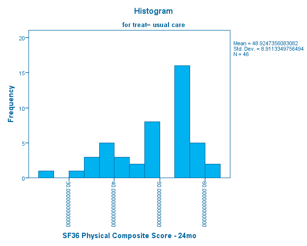

Histograms  
Histograms - treat= HELP clinic - November 12, 2017

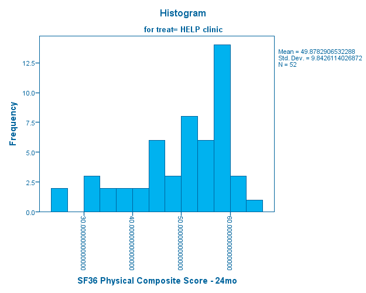

Normal Q-Q Plots  
Normal Q-Q Plots - treat= usual care - November 12, 2017

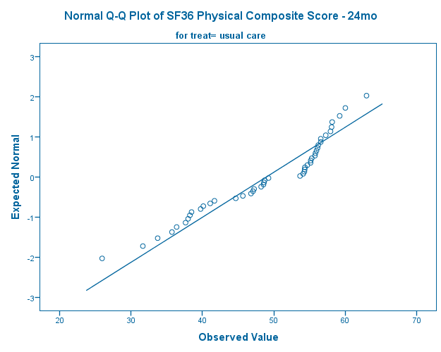

Normal Q-Q Plots  
Normal Q-Q Plots - treat= HELP clinic - November 12, 2017

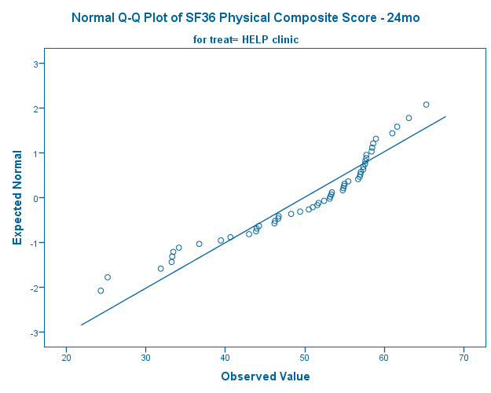

Detrended Normal Q-Q Plots  
Detrended Normal Q-Q Plots - treat= usual care - November 12, 2017

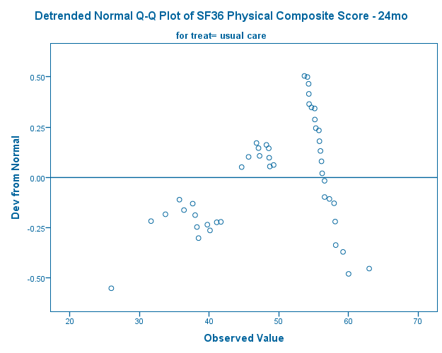

Detrended Normal Q-Q Plots  
Detrended Normal Q-Q Plots - treat= HELP clinic - November 12, 2017

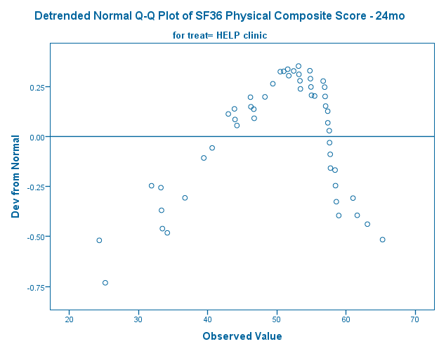

pcs4 SF36 Physical Composite Score - 24mo  
pcs4 SF36 Physical Composite Score - 24mo - Boxplot - November 12, 2017

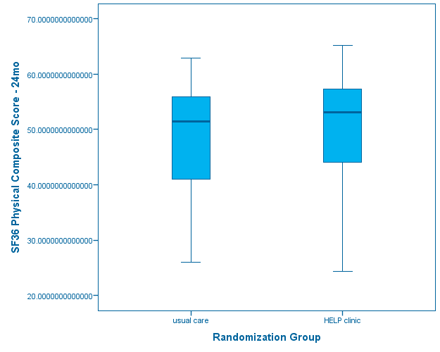

Log  
Log - Log - November 12, 2017

* compute the number of missing measurements  
* of PCS over the 5 time points.  
COMPUTE nmiss_pcs=nmiss(pcs,pcs1,pcs2,pcs3,pcs4).  
EXECUTE.  
FREQUENCIES VARIABLES=nmiss_pcs  
/ORDER=ANALYSIS.

Frequencies  
Frequencies - Statistics - November 12, 2017

StatisticsStatistics, table, nmiss_pcs, 1 layers, 0 levels of column headers and 2 levels of row headers, table with 3 columns and 4 rows

| nmiss_pcs nmiss_pcs |  |  |
| --- | --- | --- |
| N | Valid | 453 |
|  | Missing | 0 |

Frequencies  
Frequencies - nmiss_pcs - November 12, 2017

nmiss_pcsnmiss_pcs, table, 1 levels of column headers and 2 levels of row headers, table with 6 columns and 8 rows

|  |  | Frequency | Percent | Valid Percent | Cumulative Percent |
| --- | --- | --- | --- | --- | --- |
| Valid | .00 | 98 | 21.6 | 21.6 | 21.6 |
|  | 1.00 | 99 | 21.9 | 21.9 | 43.5 |
|  | 2.00 | 95 | 21.0 | 21.0 | 64.5 |
|  | 3.00 | 92 | 20.3 | 20.3 | 84.8 |
|  | 4.00 | 69 | 15.2 | 15.2 | 100.0 |
|  | Total | 453 | 100.0 | 100.0 |  |

Log  
Log - Log - November 12, 2017

COMPUTE pcs_nonemissing=nmiss_pcs < 1.  
EXECUTE.  
SORT CASES BY pcs_nonemissing.  
SPLIT FILE LAYERED BY pcs_nonemissing.  
FREQUENCIES VARIABLES=age pss_fr pcs mcs cesd  
/FORMAT=NOTABLE  
/NTILES=4  
/STATISTICS=STDDEV MINIMUM MAXIMUM MEAN  
/ORDER=ANALYSIS.

Frequencies  
Frequencies - Statistics - November 12, 2017

StatisticsStatistics, table, 2 levels of column headers and 2 levels of row headers, table with 11 columns and 13 rows

|  | pcs_nonemissing | N |  | Mean | Std. Deviation | Minimum | Maximum | Percentiles |  |  |
| --- | --- | --- | --- | --- | --- | --- | --- | --- | --- | --- |
|  |  | Valid | Missing |  |  |  |  | 25 | 50 | 75 |
| age Age at baseline (in years) | .00 | 355 | 0 | 35.11 | 7.810 | 19 | 60 | 30.00 | 34.00 | 40.00 |
|  | 1.00 | 98 | 0 | 37.63 | 7.028 | 22 | 57 | 33.00 | 37.00 | 42.00 |
| pss_fr Perceived Social Support - friends | .00 | 355 | 0 | 6.73 | 3.994 | 0 | 14 | 3.00 | 7.00 | 10.00 |
|  | 1.00 | 98 | 0 | 6.62 | 4.017 | 0 | 14 | 3.00 | 6.50 | 10.00 |
| pcs SF36 Physical Composite Score - Baseline | .00 | 355 | 0 | 48.118852180158590 | 10.672215100675604 | 14.0742912292480 | 74.8063278198242 | 40.838848114013700 | 48.814842224121100 | 56.968681335449200 |
|  | 1.00 | 98 | 0 | 47.793844884755660 | 11.234933471856774 | 20.7402915954590 | 68.1239547729492 | 38.127611160278270 | 48.924282073974595 | 56.900435447692900 |
| mcs SF36 Mental Composite Score - Baseline | .00 | 355 | 0 | 31.490017000386413 | 13.132975715455090 | 6.76292324066162 | 62.17550277709960 | 21.200042724609400 | 28.447633743286100 | 41.010501861572300 |
|  | 1.00 | 98 | 0 | 32.352849337519430 | 11.752699099788040 | 13.85299587249760 | 60.54208374023440 | 22.831596851348900 | 30.536478996276850 | 40.677231788635225 |
| cesd CESD total score - Baseline | .00 | 355 | 0 | 33.44 | 12.629 | 1 | 60 | 25.00 | 34.00 | 42.00 |
|  | 1.00 | 98 | 0 | 30.69 | 11.905 | 4 | 54 | 22.00 | 33.00 | 39.00 |

Log  
Log - Log - November 12, 2017

SPLIT FILE OFF.  
T-TEST GROUPS=pcs_nonemissing(0 1)  
/MISSING=ANALYSIS  
/VARIABLES=age pss_fr pcs mcs cesd  
/CRITERIA=CI(.95).

T-Test  
T-Test - Group Statistics - November 12, 2017

Group StatisticsGroup Statistics, table, 1 levels of column headers and 2 levels of row headers, table with 6 columns and 12 rows

|  | pcs_nonemissing | N | Mean | Std. Deviation | Std. Error Mean |
| --- | --- | --- | --- | --- | --- |
| age Age at baseline (in years) | .00 | 355 | 35.11 | 7.810 | .414 |
|  | 1.00 | 98 | 37.63 | 7.028 | .710 |
| pss_fr Perceived Social Support - friends | .00 | 355 | 6.73 | 3.994 | .212 |
|  | 1.00 | 98 | 6.62 | 4.017 | .406 |
| pcs SF36 Physical Composite Score - Baseline | .00 | 355 | 48.118852180158590 | 10.672215100675599 | .566422365564352 |
|  | 1.00 | 98 | 47.793844884755660 | 11.234933471856774 | 1.134899663447092 |
| mcs SF36 Mental Composite Score - Baseline | .00 | 355 | 31.490017000386413 | 13.132975715455100 | .697025978344117 |
|  | 1.00 | 98 | 32.352849337519430 | 11.752699099788040 | 1.187201890100737 |
| cesd CESD total score - Baseline | .00 | 355 | 33.44 | 12.629 | .670 |
|  | 1.00 | 98 | 30.69 | 11.905 | 1.203 |

T-Test  
T-Test - Independent Samples Test - November 12, 2017

Independent Samples TestIndependent Samples Test, table, 3 levels of column headers and 2 levels of row headers, table with 11 columns and 14 rows

|  |  | Levene's Test for Equality of Variances |  | t-test for Equality of Means |  |  |  |  |  |  |
| --- | --- | --- | --- | --- | --- | --- | --- | --- | --- | --- |
|  |  | F | Sig. | t | df | Sig. (2-tailed) | Mean Difference | Std. Error Difference | 95% Confidence Interval of the Difference |  |
|  |  |  |  |  |  |  |  |  | Lower | Upper |
| age Age at baseline (in years) | Equal variances assumed | 1.614 | .205 | -2.894 | 451 | .004 | -2.526 | .873 | -4.241 | -.811 |
|  | Equal variances not assumed |  |  | -3.072 | 169.022 | .002 | -2.526 | .822 | -4.148 | -.903 |
| pss_fr Perceived Social Support - friends | Equal variances assumed | .076 | .782 | .235 | 451 | .815 | .107 | .456 | -.790 | 1.004 |
|  | Equal variances not assumed |  |  | .234 | 154.042 | .815 | .107 | .458 | -.797 | 1.012 |
| pcs SF36 Physical Composite Score - Baseline | Equal variances assumed | .657 | .418 | .264 | 451 | .792 | .325007295402934 | 1.231894375417976 | -2.095958237043419 | 2.745972827849286 |
|  | Equal variances not assumed |  |  | .256 | 148.813 | .798 | .325007295402934 | 1.268397233639304 | -2.181388123164715 | 2.831402713970582 |
| mcs SF36 Mental Composite Score - Baseline | Equal variances assumed | 1.992 | .159 | -.589 | 451 | .556 | -.862832337133018 | 1.466151175279560 | -3.744168214247642 | 2.018503539981607 |
|  | Equal variances not assumed |  |  | -.627 | 169.868 | .532 | -.862832337133018 | 1.376696605046055 | -3.580469571932156 | 1.854804897666121 |
| cesd CESD total score - Baseline | Equal variances assumed | .516 | .473 | 1.930 | 451 | .054 | 2.748 | 1.424 | -.050 | 5.546 |
|  | Equal variances not assumed |  |  | 1.996 | 162.342 | .048 | 2.748 | 1.377 | .030 | 5.467 |

Log  
Log - Log - November 12, 2017

CROSSTABS  
/TABLES=female racegrp homeless BY pcs_nonemissing  
/FORMAT=AVALUE TABLES  
/STATISTICS=CHISQ  
/CELLS=COUNT EXPECTED COLUMN  
/COUNT ROUND CELL  
/METHOD=EXACT TIMER(5).

Crosstabs  
Crosstabs - Case Processing Summary - November 12, 2017

Case Processing SummaryCase Processing Summary, table, 3 levels of column headers and 1 levels of row headers, table with 7 columns and 7 rows

|  | Cases |  |  |  |  |  |
| --- | --- | --- | --- | --- | --- | --- |
|  | Valid |  | Missing |  | Total |  |
|  | N | Percent | N | Percent | N | Percent |
| female Gender of respondent * pcs_nonemissing | 453 | 100.0% | 0 | 0.0% | 453 | 100.0% |
| racegrp Racial Group of Respondent * pcs_nonemissing | 453 | 100.0% | 0 | 0.0% | 453 | 100.0% |
| homeless One or more nights on the street or shelter in past 6 months * pcs_nonemissing | 453 | 100.0% | 0 | 0.0% | 453 | 100.0% |

female Gender of respondent * pcs_nonemissing  
female Gender of respondent * pcs_nonemissing - Crosstab - November 12, 2017

CrosstabCrosstab, table, 2 levels of column headers and 3 levels of row headers, table with 6 columns and 12 rows

|  |  |  | pcs_nonemissing |  | Total |  |
| --- | --- | --- | --- | --- | --- | --- |
|  |  |  | .00 | 1.00 |  |  |
| female Gender of respondent | 0 Male | Count | 270 | 76 |  | 346 |
|  |  | Expected Count | 271.1 | 74.9 | 346.0 |  |
|  |  | % within pcs_nonemissing | 76.1% | 77.6% | 76.4% |  |
|  | 1 Female | Count | 85 | 22 | 107 |  |
|  |  | Expected Count | 83.9 | 23.1 | 107.0 |  |
|  |  | % within pcs_nonemissing | 23.9% | 22.4% | 23.6% |  |
| Total |  | Count | 355 | 98 | 453 |  |
|  |  | Expected Count | 355.0 | 98.0 | 453.0 |  |
|  |  | % within pcs_nonemissing | 100.0% | 100.0% | 100.0% |  |

female Gender of respondent * pcs_nonemissing  
female Gender of respondent * pcs_nonemissing - Chi-Square Tests - November 12, 2017

Chi-Square TestsChi-Square Tests, table, 1 levels of column headers and 1 levels of row headers, table with 7 columns and 11 rows

|  | Value | df | Asymptotic Significance (2-sided) | Exact Sig. (2-sided) | Exact Sig. (1-sided) | Point Probability |
| --- | --- | --- | --- | --- | --- | --- |
| Pearson Chi-Square | .095<sup>a</sup> | 1 | .758 | .790 | .436 |  |
| Continuity Correction<sup>b</sup> | .030 | 1 | .862 |  |  |  |
| Likelihood Ratio | .096 | 1 | .757 | .790 | .436 |  |
| Fisher's Exact Test |  |  |  | .790 | .436 |  |
| Linear-by-Linear Association | .095<sup>c</sup> | 1 | .758 | .790 | .436 | .103 |
| N of Valid Cases | 453 |  |  |  |  |  |

a. 0 cells (0.0%) have expected count less than 5. The minimum expected count is 23.15.  
b. Computed only for a 2x2 table  
c. The standardized statistic is -.308.

racegrp Racial Group of Respondent * pcs_nonemissing  
racegrp Racial Group of Respondent * pcs_nonemissing - Crosstab - November 12, 2017

CrosstabCrosstab, table, 2 levels of column headers and 3 levels of row headers, table with 6 columns and 18 rows

|  |  |  | pcs_nonemissing |  | Total |  |
| --- | --- | --- | --- | --- | --- | --- |
|  |  |  | .00 | 1.00 |  |  |
| racegrp Racial Group of Respondent | black | Count | 152 | 59 |  | 211 |
|  |  | Expected Count | 165.4 | 45.6 | 211.0 |  |
|  |  | % within pcs_nonemissing | 42.8% | 60.2% | 46.6% |  |
|  | hispanic | Count | 43 | 7 | 50 |  |
|  |  | Expected Count | 39.2 | 10.8 | 50.0 |  |
|  |  | % within pcs_nonemissing | 12.1% | 7.1% | 11.0% |  |
|  | other | Count | 21 | 5 | 26 |  |
|  |  | Expected Count | 20.4 | 5.6 | 26.0 |  |
|  |  | % within pcs_nonemissing | 5.9% | 5.1% | 5.7% |  |
|  | white | Count | 139 | 27 | 166 |  |
|  |  | Expected Count | 130.1 | 35.9 | 166.0 |  |
|  |  | % within pcs_nonemissing | 39.2% | 27.6% | 36.6% |  |
| Total |  | Count | 355 | 98 | 453 |  |
|  |  | Expected Count | 355.0 | 98.0 | 453.0 |  |
|  |  | % within pcs_nonemissing | 100.0% | 100.0% | 100.0% |  |

racegrp Racial Group of Respondent * pcs_nonemissing  
racegrp Racial Group of Respondent * pcs_nonemissing - Chi-Square Tests - November 12, 2017

Chi-Square TestsChi-Square Tests, table, 1 levels of column headers and 1 levels of row headers, table with 5 columns and 7 rows

|  | Value | df | Asymptotic Significance (2-sided) | Exact Sig. (2-sided) |
| --- | --- | --- | --- | --- |
| Pearson Chi-Square | 9.614<sup>a</sup> | 3 | .022 | .022 |
| Likelihood Ratio | 9.692 | 3 | .021 | .023 |
| Fisher's Exact Test | 9.282 |  |  | .024 |
| N of Valid Cases | 453 |  |  |  |

a. 0 cells (0.0%) have expected count less than 5. The minimum expected count is 5.62.

homeless One or more nights on the street or shelter in past 6 months * pcs_nonemissing  
homeless One or more nights on the street or shelter in past 6 months * pcs_nonemissing - Crosstab -(more) November 12, 2017(less)

CrosstabCrosstab, table, 2 levels of column headers and 3 levels of row headers, table with 6 columns and 12 rows

|  |  |  | pcs_nonemissing |  | Total |  |
| --- | --- | --- | --- | --- | --- | --- |
|  |  |  | .00 | 1.00 |  |  |
| homeless One or more nights on the street or shelter in past 6 months | 0 no | Count | 196 | 48 |  | 244 |
|  |  | Expected Count | 191.2 | 52.8 | 244.0 |  |
|  |  | % within pcs_nonemissing | 55.2% | 49.0% | 53.9% |  |
|  | 1 yes | Count | 159 | 50 | 209 |  |
|  |  | Expected Count | 163.8 | 45.2 | 209.0 |  |
|  |  | % within pcs_nonemissing | 44.8% | 51.0% | 46.1% |  |
| Total |  | Count | 355 | 98 | 453 |  |
|  |  | Expected Count | 355.0 | 98.0 | 453.0 |  |
|  |  | % within pcs_nonemissing | 100.0% | 100.0% | 100.0% |  |

homeless One or more nights on the street or shelter in past 6 months * pcs_nonemissing  
homeless One or more nights on the street or shelter in past 6 months * pcs_nonemissing - Chi-Square(more) Tests - November 12, 2017(less)

Chi-Square TestsChi-Square Tests, table, 1 levels of column headers and 1 levels of row headers, table with 7 columns and 11 rows

|  | Value | df | Asymptotic Significance (2-sided) | Exact Sig. (2-sided) | Exact Sig. (1-sided) | Point Probability |
| --- | --- | --- | --- | --- | --- | --- |
| Pearson Chi-Square | 1.200<sup>a</sup> | 1 | .273 | .303 | .163 |  |
| Continuity Correction<sup>b</sup> | .962 | 1 | .327 |  |  |  |
| Likelihood Ratio | 1.197 | 1 | .274 | .303 | .163 |  |
| Fisher's Exact Test |  |  |  | .303 | .163 |  |
| Linear-by-Linear Association | 1.197<sup>c</sup> | 1 | .274 | .303 | .163 | .050 |
| N of Valid Cases | 453 |  |  |  |  |  |

a. 0 cells (0.0%) have expected count less than 5. The minimum expected count is 45.21.  
b. Computed only for a 2x2 table  
c. The standardized statistic is 1.094.

Log  
Log - Log - November 12, 2017

* RM-ANOVA  
* uses listwise deletion  
* TIME main effect  
GLM pcs pcs1 pcs2 pcs3 pcs4  
/WSFACTOR=time 5 Polynomial  
/METHOD=SSTYPE(3)  
/PLOT=PROFILE(time)  
/EMMEANS=TABLES(OVERALL)  
/EMMEANS=TABLES(time) COMPARE ADJ(SIDAK)  
/PRINT=DESCRIPTIVE ETASQ HOMOGENEITY  
/CRITERIA=ALPHA(.05)  
/WSDESIGN=time.

General Linear Model  
General Linear Model - Warnings - November 12, 2017

WarningsWarnings, table, 0 levels of column headers and 0 levels of row headers, table with 1 columns and 2 rows

| The HOMOGENEITY specification in the PRINT subcommand will be ignored because there are no between-subjects factors. |
| --- |

General Linear Model  
General Linear Model - Within-Subjects Factors - November 12, 2017

Within-Subjects FactorsWithin-Subjects Factors, table, Measure, MEASURE_1, 1 layers, 1 levels of column headers and 1 levels of row headers, table with 2 columns and 8 rows

| MEASURE_1 MEASURE_1 |  |
| --- | --- |
| time | Dependent Variable |
| 1 | pcs |
| 2 | pcs1 |
| 3 | pcs2 |
| 4 | pcs3 |
| 5 | pcs4 |

General Linear Model  
General Linear Model - Descriptive Statistics - November 12, 2017

Descriptive StatisticsDescriptive Statistics, table, 1 levels of column headers and 1 levels of row headers, table with 4 columns and 7 rows

|  | Mean | Std. Deviation | N |
| --- | --- | --- | --- |
| pcs SF36 Physical Composite Score - Baseline | 47.793844884755664 | 11.234933471856772 | 98 |
| pcs1 SF36 Physical Composite Score - 6mo | 48.779843583398936 | 11.227499674469880 | 98 |
| pcs2 SF36 Physical Composite Score - 12mo | 49.919714567612640 | 10.107042696552082 | 98 |
| pcs3 SF36 Physical Composite Score - 18mo | 50.320825168064665 | 11.210063725810402 | 98 |
| pcs4 SF36 Physical Composite Score - 24mo | 49.430703591327266 | 9.381081862553856 | 98 |

General Linear Model  
General Linear Model - Multivariate Tests - November 12, 2017

Multivariate Tests<sup>a</sup>Multivariate Tests, table, 1 levels of column headers and 2 levels of row headers, table with 8 columns and 8 rows

| Effect |  | Value | F | Hypothesis df | Error df | Sig. | Partial Eta Squared |
| --- | --- | --- | --- | --- | --- | --- | --- |
| time | Pillai's Trace | .068 | 1.728<sup>b</sup> | 4.000 | 94.000 | .150 | .068 |
|  | Wilks' Lambda | .932 | 1.728<sup>b</sup> | 4.000 | 94.000 | .150 | .068 |
|  | Hotelling's Trace | .074 | 1.728<sup>b</sup> | 4.000 | 94.000 | .150 | .068 |
|  | Roy's Largest Root | .074 | 1.728<sup>b</sup> | 4.000 | 94.000 | .150 | .068 |

a. Design: Intercept Within Subjects Design: time  
b. Exact statistic

General Linear Model  
General Linear Model - Mauchly's Test of Sphericity - November 12, 2017

Mauchly's Test of Sphericity<sup>a</sup>Mauchly's Test of Sphericity, table, Measure, MEASURE_1, 1 layers, 2 levels of column headers and 1 levels of row headers, table with 8 columns and 8 rows

| MEASURE_1 MEASURE_1 |  |  |  |  |  |  |  |
| --- | --- | --- | --- | --- | --- | --- | --- |
| Within Subjects Effect | Mauchly's W | Approx. Chi-Square | df | Sig. | Epsilon<sup>b</sup> |  |  |
|  |  |  |  |  | Greenhouse-Geisser | Huynh-Feldt | Lower-bound |
| time | .846 | 15.989 | 9 | .067 | .931 | .972 | .250 |

Tests the null hypothesis that the error covariance matrix of the orthonormalized transformed dependent variables is proportional to an identity matrix.  
a. Design: Intercept Within Subjects Design: time  
b. May be used to adjust the degrees of freedom for the averaged tests of significance. Corrected tests are displayed in the Tests of Within-Subjects Effects table.

General Linear Model  
General Linear Model - Tests of Within-Subjects Effects - November 12, 2017

Tests of Within-Subjects EffectsTests of Within-Subjects Effects, table, Measure, MEASURE_1, 1 layers, 1 levels of column headers and 2 levels of row headers, table with 8 columns and 11 rows

| MEASURE_1 MEASURE_1 |  |  |  |  |  |  |  |
| --- | --- | --- | --- | --- | --- | --- | --- |
| Source |  | Type III Sum of Squares | df | Mean Square | F | Sig. | Partial Eta Squared |
| time | Sphericity Assumed | 388.988 | 4 | 97.247 | 2.103 | .080 | .021 |
|  | Greenhouse-Geisser | 388.988 | 3.722 | 104.498 | 2.103 | .085 | .021 |
|  | Huynh-Feldt | 388.988 | 3.889 | 100.010 | 2.103 | .082 | .021 |
|  | Lower-bound | 388.988 | 1.000 | 388.988 | 2.103 | .150 | .021 |
| Error(time) | Sphericity Assumed | 17943.978 | 388 | 46.247 |  |  |  |
|  | Greenhouse-Geisser | 17943.978 | 361.079 | 49.695 |  |  |  |
|  | Huynh-Feldt | 17943.978 | 377.280 | 47.561 |  |  |  |
|  | Lower-bound | 17943.978 | 97.000 | 184.989 |  |  |  |

General Linear Model  
General Linear Model - Tests of Within-Subjects Contrasts - November 12, 2017

Tests of Within-Subjects ContrastsTests of Within-Subjects Contrasts, table, Measure, MEASURE_1, 1 layers, 1 levels of column headers and 2 levels of row headers, table with 8 columns and 11 rows

| MEASURE_1 MEASURE_1 |  |  |  |  |  |  |  |
| --- | --- | --- | --- | --- | --- | --- | --- |
| Source | time | Type III Sum of Squares | df | Mean Square | F | Sig. | Partial Eta Squared |
| time | Linear | 227.177 | 1 | 227.177 | 3.917 | .051 | .039 |
|  | Quadratic | 141.184 | 1 | 141.184 | 2.839 | .095 | .028 |
|  | Cubic | 20.466 | 1 | 20.466 | .511 | .477 | .005 |
|  | Order 4 | .162 | 1 | .162 | .004 | .948 | .000 |
| Error(time) | Linear | 5626.074 | 97 | 58.001 |  |  |  |
|  | Quadratic | 4823.285 | 97 | 49.725 |  |  |  |
|  | Cubic | 3886.352 | 97 | 40.065 |  |  |  |
|  | Order 4 | 3608.267 | 97 | 37.199 |  |  |  |

General Linear Model  
General Linear Model - Tests of Between-Subjects Effects - November 12, 2017

Tests of Between-Subjects EffectsTests of Between-Subjects Effects, table, Measure, MEASURE_1, Transformed Variable, Average, 1 layers, 1 levels of column headers and 1 levels of row headers, table with 7 columns and 6 rows

| MEASURE_1 MEASURE_1 Average Average |  |  |  |  |  |  |
| --- | --- | --- | --- | --- | --- | --- |
| Source | Type III Sum of Squares | df | Mean Square | F | Sig. | Partial Eta Squared |
| Intercept | 1188476.702 | 1 | 1188476.702 | 3102.153 | .000 | .970 |
| Error | 37162.015 | 97 | 383.114 |  |  |  |

Estimated Marginal Means  
Estimated Marginal Means - 1. Grand Mean - November 12, 2017

1. Grand Mean1. Grand Mean, table, Measure, MEASURE_1, 1 layers, 2 levels of column headers and 0 levels of row headers, table with 4 columns and 5 rows

| MEASURE_1 MEASURE_1 |  |  |  |
| --- | --- | --- | --- |
| Mean | Std. Error | 95% Confidence Interval |  |
|  |  | Lower Bound | Upper Bound |
| 49.249 | .884 | 47.494 | 51.004 |

2. time  
2. time - Estimates - November 12, 2017

EstimatesEstimates, table, Measure, MEASURE_1, 1 layers, 2 levels of column headers and 1 levels of row headers, table with 5 columns and 9 rows

| MEASURE_1 MEASURE_1 |  |  |  |  |
| --- | --- | --- | --- | --- |
| time | Mean | Std. Error | 95% Confidence Interval |  |
|  |  |  | Lower Bound | Upper Bound |
| 1 | 47.794 | 1.135 | 45.541 | 50.046 |
| 2 | 48.780 | 1.134 | 46.529 | 51.031 |
| 3 | 49.920 | 1.021 | 47.893 | 51.946 |
| 4 | 50.321 | 1.132 | 48.073 | 52.568 |
| 5 | 49.431 | .948 | 47.550 | 51.311 |

2. time  
2. time - Pairwise Comparisons - November 12, 2017

Pairwise ComparisonsPairwise Comparisons, table, Measure, MEASURE_1, 1 layers, 2 levels of column headers and 2 levels of row headers, table with 7 columns and 26 rows

| MEASURE_1 MEASURE_1 |  |  |  |  |  |  |
| --- | --- | --- | --- | --- | --- | --- |
| (I) time | (J) time | Mean Difference (I-J) | Std. Error | Sig.<sup>a</sup> | 95% Confidence Interval for Difference<sup>a</sup> |  |
|  |  |  |  |  | Lower Bound | Upper Bound |
| 1 | 2 | -.986 | 1.031 | .985 | -3.940 | 1.968 |
|  | 3 | -2.126 | .969 | .268 | -4.903 | .651 |
|  | 4 | -2.527 | 1.024 | .143 | -5.461 | .407 |
|  | 5 | -1.637 | 1.059 | .738 | -4.669 | 1.396 |
| 2 | 1 | .986 | 1.031 | .985 | -1.968 | 3.940 |
|  | 3 | -1.140 | .937 | .924 | -3.825 | 1.545 |
|  | 4 | -1.541 | .939 | .666 | -4.230 | 1.148 |
|  | 5 | -.651 | 1.097 | 1.000 | -3.794 | 2.492 |
| 3 | 1 | 2.126 | .969 | .268 | -.651 | 4.903 |
|  | 2 | 1.140 | .937 | .924 | -1.545 | 3.825 |
|  | 4 | -.401 | .770 | 1.000 | -2.607 | 1.805 |
|  | 5 | .489 | .894 | 1.000 | -2.071 | 3.049 |
| 4 | 1 | 2.527 | 1.024 | .143 | -.407 | 5.461 |
|  | 2 | 1.541 | .939 | .666 | -1.148 | 4.230 |
|  | 3 | .401 | .770 | 1.000 | -1.805 | 2.607 |
|  | 5 | .890 | .955 | .987 | -1.845 | 3.625 |
| 5 | 1 | 1.637 | 1.059 | .738 | -1.396 | 4.669 |
|  | 2 | .651 | 1.097 | 1.000 | -2.492 | 3.794 |
|  | 3 | -.489 | .894 | 1.000 | -3.049 | 2.071 |
|  | 4 | -.890 | .955 | .987 | -3.625 | 1.845 |

Based on estimated marginal means  
a. Adjustment for multiple comparisons: Sidak.

2. time  
2. time - Multivariate Tests - November 12, 2017

Multivariate TestsMultivariate Tests, table, 1 levels of column headers and 1 levels of row headers, table with 7 columns and 8 rows

|  | Value | F | Hypothesis df | Error df | Sig. | Partial Eta Squared |
| --- | --- | --- | --- | --- | --- | --- |
| Pillai's trace | .068 | 1.728<sup>a</sup> | 4.000 | 94.000 | .150 | .068 |
| Wilks' lambda | .932 | 1.728<sup>a</sup> | 4.000 | 94.000 | .150 | .068 |
| Hotelling's trace | .074 | 1.728<sup>a</sup> | 4.000 | 94.000 | .150 | .068 |
| Roy's largest root | .074 | 1.728<sup>a</sup> | 4.000 | 94.000 | .150 | .068 |

Each F tests the multivariate effect of time. These tests are based on the linearly independent pairwise comparisons among the estimated marginal means.  
a. Exact statistic

Profile Plots  
Profile Plots - time - November 12, 2017

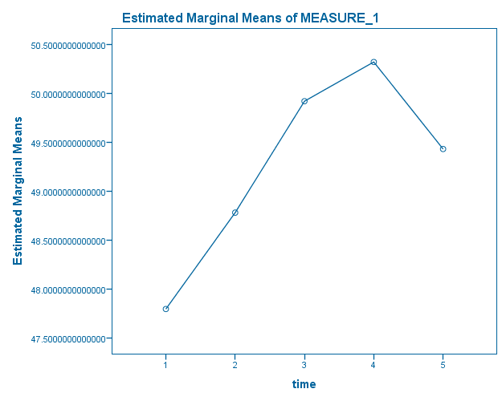

[output not shown]

[output not shown]

[output not shown]

[output not shown]

[output not shown]

[output not shown]